# PiE2 Entregable 1

Ferran Alia, Haokang Chen

2024-10-11

# Exercici 1

La funció de distribució d’una distribució Gamma és
$$f(X=x)=\frac
1{\Gamma(\alpha)\beta^\alpha}x^{\alpha-1}e^{-\frac x \beta}$$
on se’ns imposa que $\alpha = M= 2$.

```r
M=2
al=2
```

Es suposa una mostra $x=(x_1 ,\dots,x_n)$.

## Part teòrica

### Apartat a

L’estimador de $\beta$ s’anomenarà $\hat\beta$, que es pot trobar de dos maneres:

#### Moments

Sabent que $E(X)=\alpha·\beta$ i que $m_1=E(X)$:
$$m_1 =\frac 1 n\sum_{i=1}^n
x_i=\alpha\beta\implies\beta=\frac
1{n\alpha}\sum_{i=1}^nx_i\implies\hat\beta=\frac{\overline
x}{\alpha}$$
per tant l’estimador per moments de $\beta$ és $\hat\beta=\frac{\overline x}{\alpha}$

#### Màxima versemblança

La funció de verosimilitud és
$$L(x)=\mathbb
P(X_1=x_1,\dots,X_n=x_n)$$

Sabent que les mostres són independents:
$$L(X)=\prod_{i=1}^n\mathbb P(X_i=x_i)$$

Per facilitat les operacions, s’aplica el logaritme a la funció, ja que aquesta funció no mou la coordenada x del màxim:
$$l(X)=\sum_{i=1}^n\log\left(\frac
1{\Gamma(\alpha)\beta^\alpha}x^{\alpha-1}e^{-\frac x
\beta}\right)=n\log\left(\frac 1{\Gamma(\alpha)}\right)-\alpha
n\log\beta+(\alpha-1)\sum_{i=1}^n\log(x_i)-\frac 1\beta\sum_{i=1}^n
x_i$$

Derivant i igualant a 0, es te que
$$l'(X)=-\frac{\alpha n}\beta+\frac
1{\beta^2}\sum_{i=1}^n =0\implies\beta=\frac 1{\alpha n}\sum_{i=1}^n
x_i$$
per lo que el estimador de $\beta$ és
$$\hat\beta=\frac{\overline x}{\alpha}$$
que coincideix amb l’estimador per moments.

### Apartat b

La distribució de l’estimador màxim versemblant de qualsevol paràmetre és
$$\hat\theta\sim
N(\theta,I(\theta)^{-1})$$

Pel cas de la $\beta$, això és
$$\hat\beta\sim
N(\beta,I(\beta)^{-1})$$

Per la $\beta$ ja s’ha trobat un estimador, ara toca a calcular la informació de Fischer sabent que
$$I(\theta)=\mathbb E\left(-\frac{\partial^2
l}{\partial\beta^2}\right)$$
i que
$$I_n(\theta)=n·I(\theta)$$

Recuperant la primera derivada de la funció de màxima verosimilitud, si es calcula la informació d’una mostra
$$\frac{\partial l}{\partial
\beta}=-\frac\alpha\beta+\frac x{\beta^2}$$
y s’aplica la segonda derivada
$$\frac{\partial^2 l}{\partial
\beta^2}=-\frac\alpha{\beta^2}+\frac {2x}{\beta^3}\implies
I(\beta)=\frac\alpha{\beta^2}\implies
I_n(\beta)=\frac\alpha{\beta^2}n$$
per la qual cosa la distribució de l’estimador és
$$\hat\beta\sim
N\left(\beta,\frac{\beta^2}{\alpha n}\right)$$

### Apartat c

En una distribució normal $N\sim(\mu,\sigma^2)$, la variancia és $Var(X)=\sigma^2$, que pel cas de la $\beta$ passa a ser
$$Var(\beta)=\frac{\beta^2}{\alpha n}\implies S^2
=\frac{\hat\beta^2}{\alpha n}\implies S^2=\frac{\overline x^2}{\alpha^3
n}$$
on $S^2$ és l’estimador de la variancia i on s’ha fet servir l’estimador $\hat\beta$.

Per tant
$$\hat\beta\sim
N\left(\frac{\overline x}{\alpha},\frac{\overline x^2}{\alpha^3
n}\right)$$

Per trobar un interval de confiança del 90% ($\gamma=0.1$) s’ha de trobar la quantitat pivotal: una distribució que no depengui del paràmetre que estme estudiant. En aquest cas es pot trobar normalitzant la distribució normal:
$$\frac{\hat\beta-\frac{\overline
x}{\alpha}}{\frac{\overline x^2}{\alpha^3n}}\sim N(0,1)$$

Per l’interval de confiança s’han de considerar els quartil $z_{\gamma/2}$ de la distribució normal que deixa una probabilitat de $\gamma/2$ per dalt, ja que volem un interval de probabilitat $1-\gamma$:
$$\mathbb
P\left(-z_{\gamma/2}<\frac{\hat\beta-\frac{\overline
x}{\alpha}}{\frac{\overline
x^2}{\alpha^3n}}<z_{\gamma/2}\right)=1-\gamma$$
Operant per aïllar $\hat\beta$ queda que
$$\mathbb P\left(\frac{\overline
x}{\alpha}-z_{\gamma/2}·\frac{\overline
x^2}{\alpha^3n}<\hat\beta<\frac{\overline
x}{\alpha}+z_{\gamma/2}·\frac{\overline
x^2}{\alpha^3n}\right)=1-\gamma$$

Per tant, un interval de confiança del 90% per la $\hat\beta$ és
$$\hat\beta\in\left[\frac{\overline
x}{\alpha}-z_{\gamma/2}·\frac{\overline x^2}{\alpha^3n},\frac{\overline
x}{\alpha}+z_{\gamma/2}·\frac{\overline
x^2}{\alpha^3n}\right]$$

## Part pràcica

### Apartat a

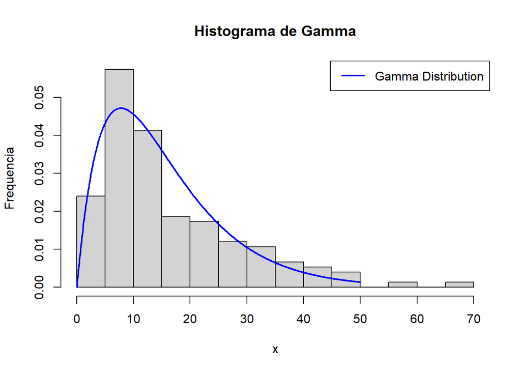

```r
set.seed(7636)

M <- 2
al <- M
be <- 7.8
n <- 150
data <- rgamma(n, shape=al, scale=be) #Mostra aleatòria de 150 valors seguint una distribució gamma

# Plot dels valors (histograma) junt amb la funció de distribució de la Gamma
hist(data, freq = FALSE, breaks = 20, main = "Histograma de Gamma",
     xlab = "x", ylab = "Frequencia", col = "lightgray", border = "black")

x <- seq(0, 50, by = 0.1)
y <- dgamma(x, shape=al, scale=be)
lines(x, y, col = "blue", lwd = 2)

legend("topright", legend = "Gamma Distribution", col = "blue", lwd = 2)
```

A l’histograma de la Gamma es pot veure que, tot i que hi ha petites diferències, les mostres segueixen la funció de distribució de la Gamma.

### Apartat b

```r
dif_mean_exp_teo = abs(al*be-mean(data))
dif_mean_exp_teo #Diferència entre la mitjana experimental i la teòrica
```

```
## [1] 0.5579315
```

```r
dif_var_exp_teo = abs(al*be*be-var(data))
dif_var_exp_teo #Diferència entre la variança experimental i la teòrica
```

```
## [1] 27.81795
```

### Apartat c

```r
emv_be=mean(data)/al #Càlcul de la beta experimental
emv_be
```

```
## [1] 8.078966
```

### Apartat d

```r
IC_low <- mean(data)/al - qnorm(0.95)*(mean(data)^2/(al^3*n))
IC_high <- mean(data)/al + qnorm(0.95)*(mean(data)^2/(al^3*n))
IC_low
```

```
## [1] 7.721102
```

```r
IC_high
```

```
## [1] 8.436829
```

# Exercici 2

Primer de tot, s’importen les dades des de l’arxiu csv.

```r
library(readr)
dades2 <- read.csv("dades2.csv", sep = ";")
```

## Apartat a

Com es vol comparar les salsitxes dels dos tipus, es dividiran les dades en dos taules diferents, i es compararan els valors de sodi de cada tipus de carn amb un histograma:

```r
vedella <- dades2[dades2$Tipus == "Vedella", ]
gallDIndi <- dades2[dades2$Tipus == "Gall d'indi", ]

avg_sodi_vedella = mean(vedella$Sodi)
avg_sodi_vedella
```

```
## [1] 581.2944
```

```r
avg_sodi_gallDindi = mean(gallDIndi$Sodi)
avg_sodi_gallDindi
```

```
## [1] 505.1678
```

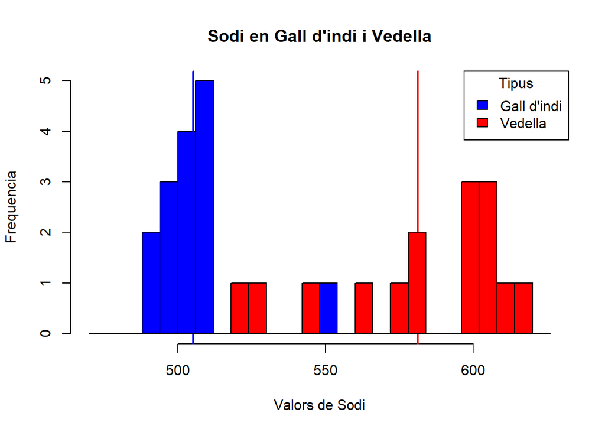

```r
breaks = seq(470, 630, by = 6)

hist(gallDIndi$Sodi,
     main = "Sodi en Gall d'indi i Vedella",
     xlab = "Valors de Sodi",
     ylab = "Frequencia",
     col = "blue",
     border = "black",
     breaks = breaks)

abline(v = avg_sodi_gallDindi, col = "blue", lwd = 2)
abline(v = avg_sodi_vedella, col = "red", lwd = 2)

hist(vedella$Sodi,
     col = "red",
     border = "black",
     breaks = breaks,
     add = TRUE)

legend("topright",
       legend = c("Gall d'indi", "Vedella"),
       fill = c("blue", "red"),
       border = "black",
       title = "Tipus")
```

```r
par(mfrow = c(1, 1))
```

## Apartat b

Només veient els histogrames es pot notar que els valors de sodi a la vedella son força més dispersos que els del gall d’indi. Si es calculen les variancies a partir de la mostra, es troba que, efectivament, així és.

```r
var_sodi_gallDindi = var(gallDIndi$Sodi)
var_sodi_vedella = var(vedella$Sodi)
abs(var_sodi_gallDindi - var_sodi_vedella)
```

```
## [1] 737.8411
```

## Apartat c

Ara es vol comparar el gall d’indi amb la vedella:

```r
t_test_result <- t.test(vedella$Sodi, gallDIndi$Sodi, var.equal = FALSE)
t_test_result
```

```
##
##  Welch Two Sample t-test
##
## data:  vedella$Sodi and gallDIndi$Sodi
## t = 8.793, df = 19.571, p-value = 3.141e-08
## alternative hypothesis: true difference in means is not equal to 0
## 95 percent confidence interval:
##  58.04171 94.21162
## sample estimates:
## mean of x mean of y
##  581.2944  505.1678
```

Això es fa primer amb el mètode dels punts critics:

```r
df <- t_test_result$parameter
alpha <- 0.05

t_value <- t_test_result$statistic
t_critic <- qt(1 - alpha/2, df)

t_value
```

```
##        t
## 8.792985
```

```r
t_critic
```

```
## [1] 2.088897
```

```r
if(abs(t_value) > t_critic) {
  print("Rebutgem la hipòtesi nul·la: hi ha una diferència significativa.")
} else {
  print("No podem rebutjar la hipòtesi nul·la: la diferència no és significativa.")
}
```

```
## [1] "Rebutgem la hipòtesi nul·la: hi ha una diferència significativa."
```

També es veu clarament que el p-valor calculat és inferior a l’alfa que s’estaà fent servir.

```r
if(abs(t_test_result$p.value) < alpha) {
  print("Rebutgem la hipòtesi nul·la: hi ha una diferència significativa.")
} else {
  print("No podem rebutjar la hipòtesi nul·la: la diferència no és significativa.")
}
```

```
## [1] "Rebutgem la hipòtesi nul·la: hi ha una diferència significativa."
```

I el mateix passa amb els intervals de confiança:

```r
t_test_result$conf.int
```

```
## [1] 58.04171 94.21162
## attr(,"conf.level")
## [1] 0.95
```

Es veu que no inclou el zero, per tant la probabilitat de que la diferencia no sigui significativa es menor al 5%.

## Apartat d

```r
t_test_sodi <- t.test(gallDIndi$Sodi, mu = 500, alternative = "greater")
t_test_sodi
```

```
##
##  One Sample t-test
##
## data:  gallDIndi$Sodi
## t = 1.4398, df = 14, p-value = 0.08596
## alternative hypothesis: true mean is greater than 500
## 95 percent confidence interval:
##  498.846     Inf
## sample estimates:
## mean of x
##  505.1678
```

## Apartat e

Com el sodi de la vedella i del gall d’indi segueixen normals, la seva diferencia també seguirà una normal $N(\mu_v-\mu_g, \frac{\sigma_v}{\sqrt{n_v}}+\frac{\sigma_g}{\sqrt{n_g}})$, substituïnt les sigmes per les seves estimacions, trobem que
$$\frac{\overline x_{v}-\overline
x_{g}-(\mu_{v}-\mu_{g})}{\sqrt{\frac{S_{v}^{2}}{n_{v}}+\frac{S_{g}^{2}}{n_{g}}}}\sim
t_\nu$$
on
$$\large\nu =
\frac{\left(\frac{S_{v}^{2}}{n_{v}}+\frac{S_{g}^{2}}{n_{g}}\right)^{2}}{\frac{\frac{S_{v}^{2}}{n_{v-1}}^{2}}{n_{v-1}}+\frac{\frac{S_{g}^{2}}{n_{g-1}}^{2}}{n_{g-1}}}$$

Operant amb aquesta distribució s’arriba a l’interval de confiança demanat. Aquest és el que s’ha trobat a l’apartat c amb el t.test:

```r
t_test_result$conf.int
```

```
## [1] 58.04171 94.21162
## attr(,"conf.level")
## [1] 0.95
```

Per reduïr l’amplada d’aquest interval, podem fer-ho de dues maneres: augmentant el número de mostres ($n$) o reduïnt el nivell de confiança (el 95%).

# Exercici 3

Importem les dades de “Ocells2.csv”

```r
library(readr)
ocells <- read.csv("Ocells2.csv", sep=";")
```

Es suposa que les dades segueixen una distribució geomètrica, de fòrmula
$$p(X=k)=p(1-p)^{k-1}$$

El test de hipotesis és $H_o:p=0.3,\quad H_1:p\neq0.3$.

Per resoldre aquesta hipotesis s’utilitza el test de raó de versemblança, mitjançant la distribució $-2\log(\lambda(\underset\sim x))\sim\chi^{2}_d$.

La funció de màxima verosimilitud per la distribució geomètrica és:
$$L(p;\underline x)=\prod_{i=1}^n
(p(1-p)^{k-1})=p^n\prod_{i=1}^n(1-p)^{k_i-1}$$

Si s’hi aplica un logaritme:
$$l(p;\underline x)=n\log(p)+\sum_{i=1}^n\log(1-p)^
{k-i}=n\log (p)+\log(1-p)\left[\sum_{i=1}^n(k_i)-n\right]$$

Buscant el màxim d’aquesta funció es pot trobar la $p$ de màxima verosimilitud:
$$l'(p,\underline x)=0\implies\frac n p -\frac
1{1-p}\left[\sum_{i=1}^n (k_i)-n\right]=0\implies p=\frac 1{\frac 1 n
\sum_{i=1}^n k_i}=\frac 1{\overline k}$$

Amb aquesta $p$ es pot trobar l’estadístic de prova, ja que
$$-2\log(\lambda(\underline x))=-2(l(\overset\sim
p;\underline x)-l(\hat p;\underline x))$$
on $\overset\sim p$ és l’estimador màxim versemblant en el submodel ($p=0.3$) i $\hat p$ és l’estimador màxim versemblant en el model general.

Per tant, queda que l’estadístic de prova és
$$-2\left(n(\log(0.3)-\log(\hat
p))+\left[\sum_{i=1}^n (k_i) -n\right](\log(0.7)-\log(1-\hat
p))\right)\sim\chi^{2}_d$$
on $d=\dim(\overset\sim p)-\dim(\hat p)=1-0=1$

Al codi escrit a continuació s’elavoren tots els càlculs numèrics per resoltre el test de hipòtesis.

```r
alpha <- 0.05
p <- 0.3
n <- sum(ocells$Frequencia)
sum_ki <- sum(ocells$Frequencia*ocells$Valor)
mean_k <- sum_ki/n
estad_prova <- -2*(n*(log(p)-log(1/mean_k))+(log(1-p)-log(1-1/mean_k))*(sum_ki-n))
dist_ref <- qchisq(1-alpha, 1)

estad_prova >= dist_ref # Rebutjar si True
```

```
## [1] FALSE
```

```r
p_value <- 1- pchisq(estad_prova, 1)

p_value <= alpha # Rebutjar si True
```

```
## [1] FALSE
```

No rebutgem $H_o$